# Des mathématiques pour faire rouler les trains

Guillaume Dalle

Cycle SMAI & Musée des arts et métiers

2025-09-10

# Introduction

## La recherche, c’est quoi ?

Plein de métiers différents à la fois !

- 📖 Lire
- 🤔 Réfléchir
- ⌨️ Coder
- 📜 Écrire
- 🎤 Présenter
- 🧑‍🏫 Enseigner
- 🧑‍🎓 Encadrer
- 📂 Organiser
- 💵 Financer

## La recherche en transports

De multiples disciplines mobilisées :

- 🏭 Ingénierie
- 🤑 Économie
- 🗺️ Géographie
- 🧑‍🤝‍🧑 Sociologie
- 💻 Informatique
- ➕ Mathématiques ?

## Mon parcours

1. Lycée scientifique
2. Classe préparatoire maths-physique
3. École d’ingénieurs
4. Thèse (*comment prédire et éviter les retards de trains ?*)
5. Postdoctorat (*comment analyser des réseaux complexes ?*)
6. Chercheur (*comment mutualiser les livraisons de marchandises ?*)

## La planification ferroviaire

[figure not shown]

Étapes du processus (Schlechte 2012)

Acteurs impliqués :

- 🚄 Entreprises ferroviaires (RU)
- 🛤️ Gestionnaire d’infrastructure (IM)

Échelles temporelles :

- 👴 Stratégique : A-5
- 📆 Tactique : A-1 à M-1
- ⌚ Opérationnelle : M-1 à J-1

## Focus sur l’allocation d’itinéraires

But : amener chaque train de son point de départ à son point d’arrivée.

[figure not shown]

Le challenge Flatland (https://flatland-association.github.io/)

Problème d’**optimisation** sur un **graphe**, de **complexité** exponentielle.

# Notions de théorie des graphes

## Définition

Un graphe $G = (N, A)$ est composé

- d’un ensemble de noeuds $i \in N$
- d’un ensemble d’arêtes $a = (i, j) \in A$

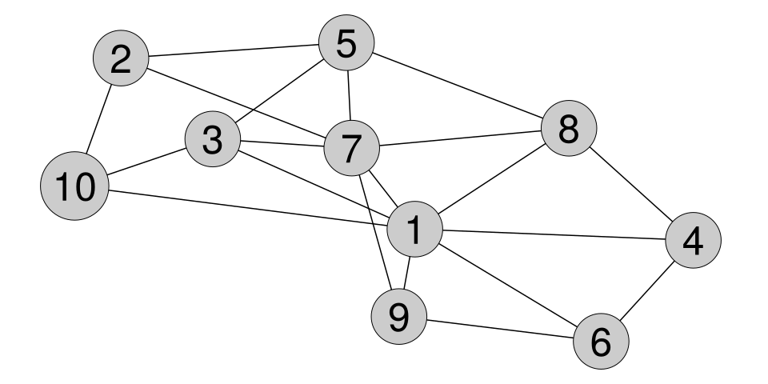

Permet de représenter des connexions entre différentes entités.

## Origines : les 7 ponts de Königsberg

Le premier problème de théorie des graphes fut posé par Euler.

[figure not shown]

Peut-on traverser tous ces ponts une fois chacun sans revenir sur ses pas ?

## Applications

- Communications
- Réseaux sociaux
- Molécules / protéines

[figure not shown]

Structure de communauté dans un graphe (Abbe 2018)

## Le réseau ferroviaire comme graphe

Un noeud ne correspond pas toujours à une localisation physique !

[figure not shown]

Représentation graphique d’un réseau avec orientation (Laurent et al. 2021)

# Notions d’optimisation

## Est-ce de l’IA ?

L’Intelligence Artificielle désigne un ensemble d’algorithmes permettant d’automatiser des tâches typiquement attribuées aux humains.

**Prédiction**

Anticiper un phénomène inconnu ou futur.

[figure not shown]

**Génération**

Produire des médias à partir de consignes et d’exemples.

[figure not shown]

**Décision**

Planifier l’usage de ressources limitées.

[figure not shown]

## Vous apprendrez cette année à résoudre des problèmes d’optimisation

Trouver le minimum d’une fonction $x \in \mathbb{R} \longmapsto f(x)$.

Il suffit de calculer sa dérivée $f'(x)$ (pente de la courbe) et de résoudre $f'(x) = 0$.

Problème : comment fait-on si $x$ doit satisfaire des contraintes ?

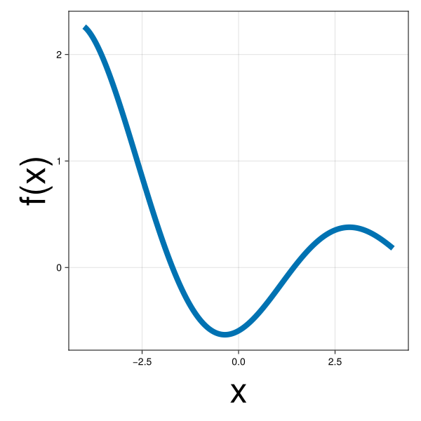

## Un problème sous contrainte

On me donne une tôle d’aluminium de surface $1 m^2$ pour fabriquer une casserole. Comment obtenir le plus grand volume ?

- La casserole a un rayon $r$ et une hauteur $h$.
- Sa surface est donnée par $S(r, h) = \pi r^2 + 2 \pi r h$.
- Son volume est donné par $V(r, h) = \pi r^2 h$.

Problème d’optimisation :

$$\begin{aligned}\max_{r,h} \quad & V(r, h) \\ \text{s.c.} \quad & S(r, h) \leq 1 \\ & r \geq 0 \\ & h \geq 0\end{aligned}$$

## Modéliser la réalité

Pour que l’ordinateur aide à la décision, il faut expliciter le problème :

- Données
- Variables
- Contraintes
- Objectif

**Simplification nécessaire**

“Tous les modèles sont faux, mais certains sont utiles.” (George Box)

## Données du problème

- Topographie du réseau : un graphe dirigé $G = (N, A)$
- Durée de la journée $T$
- Ensemble $V$ de voyages, chaque voyage $v \in V$ possédant :
  - Station de depart $s_v^d$ et d’arrivée $s_v^a$
  - Heure de départ $h_v^d$ et d’arrivée $h_v^a$ théoriques

## Variables de décision

Itinéraire de chaque voyage : suite de noeuds $(n_v^1, ..., n_v^T)$

Heures d’arrivée et de départ ? Déterminées par les contraintes.

[figure not shown]

Décider ce que fait chaque train à chaque intersection (Laurent et al. 2021)

## Contraintes à respecter

- Chaque voyage existe sur le réseau : $(n_v^t, n_v^{t+1}) \in A$
- Chaque voyage part de sa station de départ : $n_v^1 = s_v^d$
- Chaque voyage arrive à sa station d’arrivée : $n_v^T = s_v^a$
- Chaque voyage attend son heure de départ : $n_v^1 = n_v^2 = \dots = n_v^{h_v^d}$
- Deux voyages n’occupent pas le même noeud en même temps : $n_v^t \neq n_{v'}^t$

## Fonction objectif

Retard d’un voyage :
$$r_v = \max(0, \delta_v) \quad \text{où} \quad \delta_v = \text{ heure d'arrivée réelle } - h_v^a$$

“Coût” à minimiser : plusieurs choix possibles pour agréger les voyages

- Retard total $r_1 + r_2 + \dots + r_V$
- Plus grand retard $\max (r_1, r_2, \dots, r_V)$

## Résolution

Les problèmes d’optimisation réalistes sont résolus par des algorithmes, implémentés sous forme de code informatique.

Critères d’évaluation :

- ✅ Terminaison
- 👉 Correction
- 🥇 Optimalité
- 🏃 Complexité

# Notions de complexité

## Taille de l’entrée & efficacité

Nos données d’entrée se mesurent par :

- le nombre de noeuds du graphe $N$
- le nombre d’arêtes du graphe $A$
- le nombre de voyages $V$

L’efficacité d’un algorithme se mesure par :

- le temps de calcul
- la mémoire utilisée

Plus l’entrée est grande, plus l’algorithme utilise de ressources.

## Polynomial vs exponentiel

On mesure la complexité en opérations arithmétiques ($+$, $-$, $\times$, $\div$). Supposons que chacune prend $1$ nanoseconde.

[output not shown]

## Exemples

| Problème | Complexité | Algorithme |
| --- | --- | --- |
| Trouver le minimum d’une liste de nombres | $N$ | Parcours simple |
| Trier une liste de nombres | $N \log N$ | Tri fusion |
| Calculer un seul itinéraire | $N \log N$ | A* |
| Calculer plusieurs itinéraires compatibles | exponentielle | ? |

# Le rôle des benchmarks

## Pourquoi se comparer ?

On sait résoudre des problèmes exponentiels, mais pas toujours exactement.

Benchmark = scénario standardisé pour évaluer les différentes approches.

[figure not shown]

Différentes méthodes de résolution pour Flatland (Laurent et al. 2021)

Nécessite de trouver des points communs entre différents problèmes.

## Simplification 1 : de la réalité à Flatland

Flatland est un problème plus simple que la réalité :

- Réseau assimilé à une grille
- Commande centralisée
- Vitesse constante
- Pas de stations intermédiaires
- Pas de mécanisme de sécurité

[figure not shown]

Un paysage suisse bucolique (https://flatland-association.github.io)

## Simplification 2 : de Flatland au MAPF

Le *Multi-Agent PathFinding* est un problème encore plus simple que Flatland :

- Cellules plus simples (vides ou obstacles)
- Les agents sont ponctuels
- Pas d’accidents aléatoires

Très utile pour développer de nouveaux algorithmes !

[figure not shown]

Une instance de MAPF à deux agents (Gao et al. 2024)

## Le benchmark MAPF

Instances de tailles et natures variées (Stern et al. 2019).

[figure not shown]

Villes

[figure not shown]

Jeux vidéo

[figure not shown]

Labyrinthes

[figure not shown]

Pièces

[figure not shown]

Aléatoires

## Comment gagner le challenge Flatland ?

Avec des techniques éprouvées pour un problème plus simple (MAPF) :

1. Recherche d’itinéraire efficace pour un seul train
2. Gestion des conflits pour plusieurs trains

Découvrons la stratégie de l’équipe gagnante !

[figure not shown]

Les deadlocks sont un défi majeur (Li et al. 2021)

# Itinéraire pour un seul train

## Existe-t-il toujours un plus court chemin ?

Pas si le graphe est déconnecté

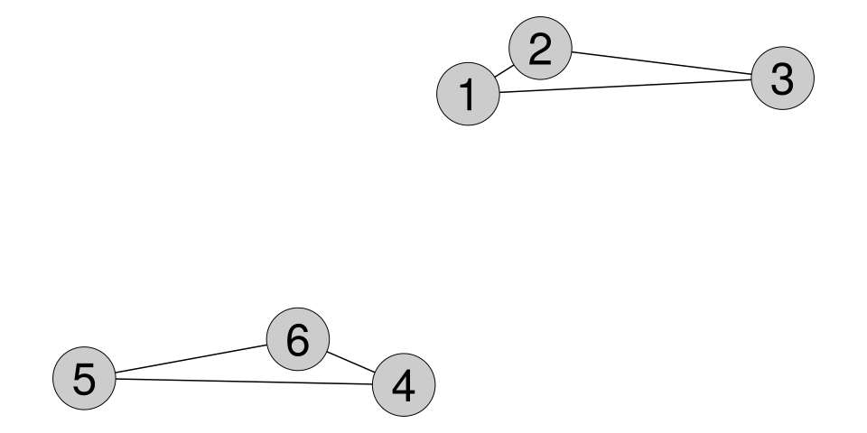

Pas si le graphe a des cycles de coût négatif

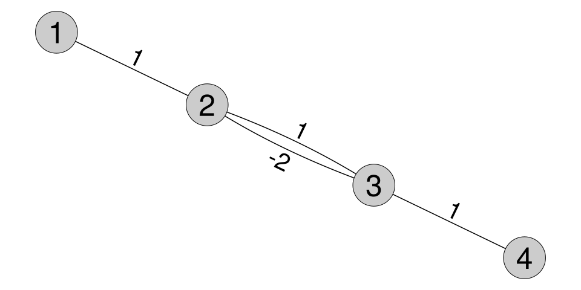

## Recherche en largeur : exploration naïve

Explorer le graphe par cercles concentriques autour du point de départ.

**Avantage**

Très facile à appliquer

**Défaut**

Exploration à l’aveugle

[Lien de visualisation](https://tobinatore.github.io/algovis/pathfinding.html)

## Algorithme A* : exploration guidée

Prioriser les sommets selon la somme de deux quantités :

- distance exacte depuis l’origine $g(n)$
- distance *approximative* jusqu’à la destination $h(n)$

**Avantage**

Évite de se disperser

**Défaut**

Nécessite une bonne “heuristique”

[Lien de visualisation](https://tobinatore.github.io/algovis/pathfinding.html)

## Est-ce le meilleur algorithme ?

A* est le meilleur algorithme de sa “famille” si l’heuristique utilisée est :

- admissible : sous-estime toujours le coût du chemin restant
- consistente : satisfait l’inégalité triangulaire $h(j) \leq w(i, j) + h(i)$

Mais on peut faire mieux si on a accès au graphe en avance (Bast et al. 2016).

[figure not shown]

# Itinéraires pour plusieurs trains

## Une explosion des possibilités

Idéalement, on voudrait trouver les itinéraires pour chaque agent en parallèle.

Plus les agents sont nombreux, plus on dévie du chemin optimal.

[Lien de visualisation](https://tracker.pathfinding.ai/instances?mapId=63761f255d814f08ecdbf3a3&reason=unknown&scenId=63761f265d814f08ecdbf3f5&instanceId=63762a215d814f08ece655a0&solutionId=6411363aa77d7971656050c2&source=submitted)

## Recherche arborescente : c’est trop long !

Idée (*Conflict-Based Search*) : dès qu’on rencontre un conflit, explorer les deux possibilités engendrées.

[figure not shown]

Il faut explorer toutes les feuilles de l’arbre (Wang et al. 2025)

**Avantage**

Trouve une solution optimale

**Défaut**

Complexité exponentielle

## Planification priorisée

Idée : planifier les agents un par un, et les considérer comme obstacles figés ensuite.

[figure not shown]

L’ordre de priorité est important (Wang et al. 2025)

**Avantage**

Très rapide à exécuter

**Défaut**

Ne trouve pas forcément de solution (optimale)

# Conclusion

## Leçons à retenir

- 🚦 Les maths peuvent servir à décrire et résoudre des problèmes d’optimisation en transport.
- 😱 Certains sont faciles (plus court chemin), d’autres difficiles (Flatland).
- 📊 Simplifier et généraliser le problème permet des approches générales et comparables.
- 🫠 En pratique, tout est toujours plus compliqué (c’est ça qui est fun).

## Des questions ?

Mon site web pour plus d’infos : https://gdalle.github.io/

## Références

Abbe, Emmanuel. 2018. “Community Detection and Stochastic Block Models: Recent Developments.” *Journal of Machine Learning Research* 18 (177): 1–86. http://jmlr.org/papers/v18/16-480.html.

Bast, Hannah, Daniel Delling, Andrew Goldberg, Matthias Müller-Hannemann, Thomas Pajor, Peter Sanders, Dorothea Wagner, and Renato F. Werneck. 2016. “Route Planning in Transportation Networks.” In *Algorithm Engineering: Selected Results and Surveys*, edited by Lasse Kliemann and Peter Sanders, 19–80. Lecture Notes in Computer Science. Cham: Springer International Publishing. https://doi.org/10.1007/978-3-319-49487-6_2.

Gao, Jianqi, Yanjie Li, Xinyi Li, Kejian Yan, Ke Lin, and Xinyu Wu. 2024. “A Review of Graph-Based Multi-Agent Pathfinding Solvers: From Classical to Beyond Classical.” *Knowledge-Based Systems* 283 (January): 111121. https://doi.org/10.1016/j.knosys.2023.111121.

Laurent, Florian, Manuel Schneider, Christian Scheller, Jeremy Watson, Jiaoyang Li, Zhe Chen, Yi Zheng, et al. 2021. “Flatland Competition 2020: MAPF and MARL for Efficient Train Coordination on a Grid World.” March 30, 2021. http://arxiv.org/abs/2103.16511.

Li, Jiaoyang, Zhe Chen, Yi Zheng, Shao-Hung Chan, Daniel Harabor, Peter J. Stuckey, Hang Ma, and Sven Koenig. 2021. “Scalable Rail Planning and Replanning: Winning the 2020 Flatland Challenge.” *Proceedings of the International Conference on Automated Planning and Scheduling* 31 (May): 477–85. https://ojs.aaai.org/index.php/ICAPS/article/view/15994.

Schlechte, Thomas. 2012. “Railway Track Allocation: Models and Algorithms.” PhD thesis, Technische Universität Berlin. https://opus4.kobv.de/opus4-zib/frontdoor/index/index/docId/1489.

Stern, Roni, Nathan Sturtevant, Ariel Felner, Sven Koenig, Hang Ma, Thayne Walker, Jiaoyang Li, et al. 2019. “Multi-Agent Pathfinding: Definitions, Variants, and Benchmarks.” *Proceedings of the International Symposium on Combinatorial Search* 10 (1, 1): 151–58. https://doi.org/10.1609/socs.v10i1.18510.

Wang, Shiyue, Haozheng Xu, Yuhan Zhang, Jingran Lin, Changhong Lu, Xiangfeng Wang, and Wenhao Li. 2025. “Where Paths Collide: A Comprehensive Survey of Classic and Learning-Based Multi-Agent Pathfinding.” May 25, 2025. https://doi.org/10.48550/arXiv.2505.19219.